# Week6Lab

JamesDale

2/27/2020

## Excercise 1

#### In the first paragraph, several key findings are reported. Do these percentages appear to be sample statistics (derived from the data sample) or population parameters?

The statistic are to be reflective of the population however they must have been derived from the survery which is a sample.

## Excercise 2

#### The title of the report is “Global Index of Religiosity and Atheism”. To generalize the report’s findings to the global human population, what must we assume about the sampling method? Does that seem like a reasonable assumption?

We assume the observations are independent and the sample size is less than 10% of the populations. Given the study claim this is a random sample it is reasonable to assume the observations are independent Given the large number of people living in each country it is reasonable to say the sample size is less than 10% of the population.

## Excercise 3

### What does each row of Table 6 correspond to? What does each row of atheism correspond to?

Each row of of Table 6 corresponds to the proportion of the given sample size of the country given in the countries column for each category.

#### Example of Table 6

| Countries | Sample Size | Religious | Not Religious | Atheist | Dont Know |
| --- | --- | --- | --- | --- | --- |
| Afghanistan | 1031 | 83% | 15% | 0% | 2% |

The cell 83% means 83% of 1031 of respondents from Afghanistan consider themselves religious.

```r
head(atheism, n=3)
```

```
##   nationality    response year
## 1 Afghanistan non-atheist 2012
## 2 Afghanistan non-atheist 2012
## 3 Afghanistan non-atheist 2012
```

Each row in the atheism dataset refers to each response as seen above. This could be considered the “raw” response values.

## Excercise 4

Using the command below, create a new dataframe called us12 that contains only the rows in atheism associated with respondents to the 2012 survey from the United States. Next, calculate the proportion of atheist responses. Does it agree with the percentage in Table 6? If not, why?

```r
us12 <- subset(atheism, nationality == "United States" & year == "2012")
nrow(subset(us12, response=="atheist"))/nrow(us12)
```

```
## [1] 0.0499002
```

Based on the calculation above I agree with the statistic on Table 6

## Exercise 6

Write out the conditions for inference to construct a 95% confidence interval for the proportion of atheists in the United States in 2012. Are you confident all conditions are met?

#### Conditions for inference

- Independent observations - we assume this is met because this is a random sample
- Population normality - 1002x0.05 = 50, 1002x0.95=952

```r
inference(us12$response, est = "proportion", type = "ci", method = "theoretical",
           success = "atheist")
```

```
## Single proportion -- success: atheist
## Summary statistics:
```

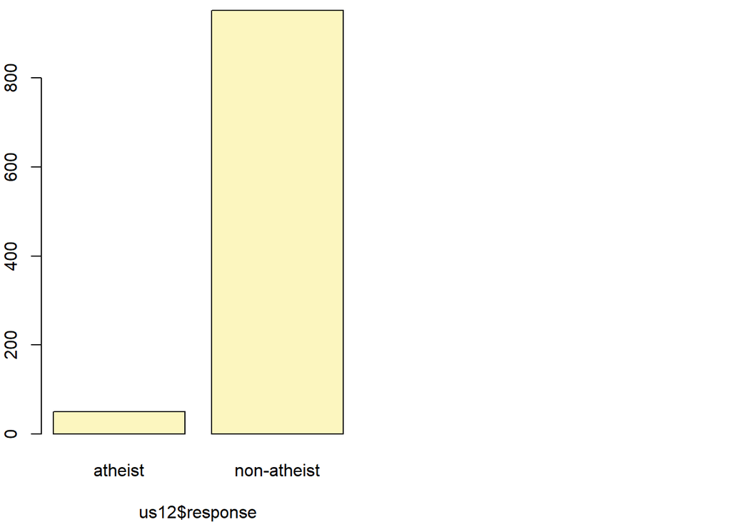

```
## p_hat = 0.0499 ;  n = 1002
## Check conditions: number of successes = 50 ; number of failures = 952
## Standard error = 0.0069
## 95 % Confidence interval = ( 0.0364 , 0.0634 )
```

## Exercise 6

Based on the R output, what is the margin of error for the estimate of the proportion of the proportion of atheists in US in 2012?

```r
ex6_margin_error <- 1.96 * 0.0069
ex6_margin_error
```

```
## [1] 0.013524
```

## Exercise 7

Using the inference function, calculate confidence intervals for the proportion of atheists in 2012 in two other countries of your choice, and report the associated margins of error. Be sure to note whether the conditions for inference are met. It may be helpful to create new data sets for each of the two countries first, and then use these data sets in the inference function to construct the confidence intervals.

```r
unique(atheism$nationality)
```

```
##  [1] Afghanistan
##  [2] Argentina
##  [3] Armenia
##  [4] Australia
##  [5] Austria
##  [6] Azerbaijan
##  [7] Belgium
##  [8] Bosnia and Herzegovina
##  [9] Brazil
## [10] Bulgaria
## [11] Cameroon
## [12] Canada
## [13] China
## [14] Colombia
## [15] Czech Republic
```

[output cut: 43 more lines]

#### Margin of error for Canada

```r
can12 <- subset(atheism, nationality == "Canada" & year == "2012")
# Conditions are met
summary(can12)
```

```
##       nationality          response        year
##  Canada     :1002   atheist    : 90   Min.   :2012
##  Afghanistan:   0   non-atheist:912   1st Qu.:2012
##  Argentina  :   0                     Median :2012
##  Armenia    :   0                     Mean   :2012
##  Australia  :   0                     3rd Qu.:2012
##  Austria    :   0                     Max.   :2012
##  (Other)    :   0
```

```r
inference(can12$response, est = "proportion", type = "ci", method = "theoretical",
           success = "atheist")
```

```
## Single proportion -- success: atheist
## Summary statistics:
```

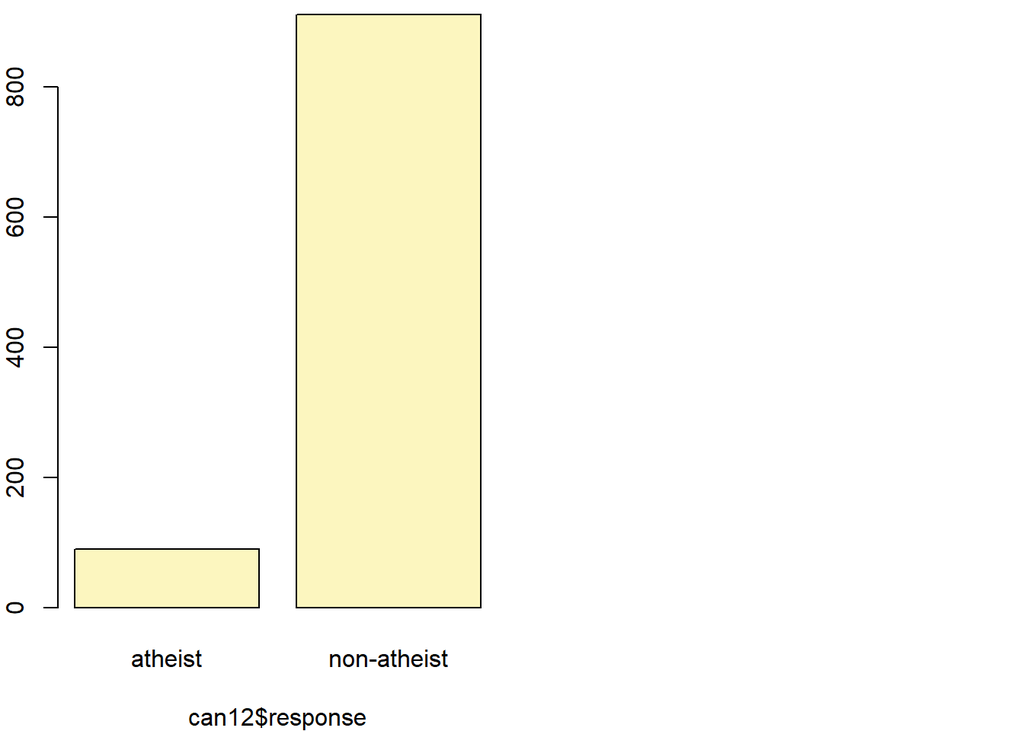

```
## p_hat = 0.0898 ;  n = 1002
## Check conditions: number of successes = 90 ; number of failures = 912
## Standard error = 0.009
## 95 % Confidence interval = ( 0.0721 , 0.1075 )
```

```r
can_margin_error <- 1.96 * 0.009
can_margin_error
```

```
## [1] 0.01764
```

#### Margin of error for Italy

```r
italy12 <- subset(atheism, nationality == "Italy" & year == "2012")
# Conditions are met
summary(italy12)
```

```
##       nationality         response        year
##  Italy      :987   atheist    : 79   Min.   :2012
##  Afghanistan:  0   non-atheist:908   1st Qu.:2012
##  Argentina  :  0                     Median :2012
##  Armenia    :  0                     Mean   :2012
##  Australia  :  0                     3rd Qu.:2012
##  Austria    :  0                     Max.   :2012
##  (Other)    :  0
```

```r
inference(italy12$response, est = "proportion", type = "ci", method = "theoretical",
           success = "atheist")
```

```
## Single proportion -- success: atheist
## Summary statistics:
```

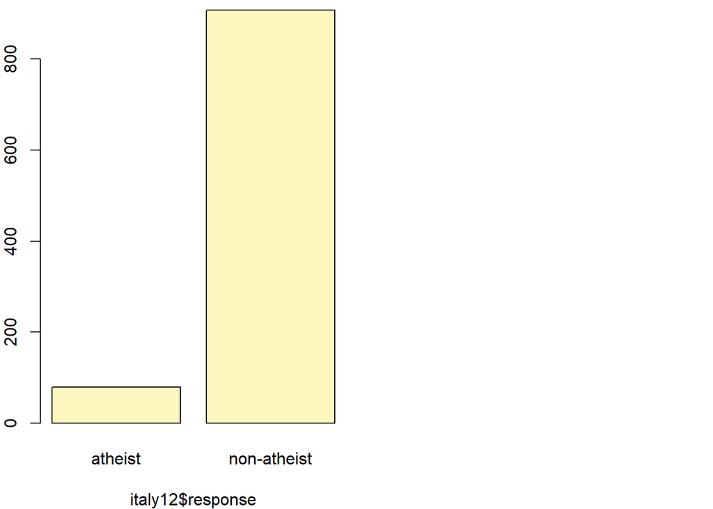

```
## p_hat = 0.08 ;  n = 987
## Check conditions: number of successes = 79 ; number of failures = 908
## Standard error = 0.0086
## 95 % Confidence interval = ( 0.0631 , 0.097 )
```

```r
italy_margin_error <- 1.96 * 0.0086
italy_margin_error
```

```
## [1] 0.016856
```

## How does the proportion affect the margin of error?

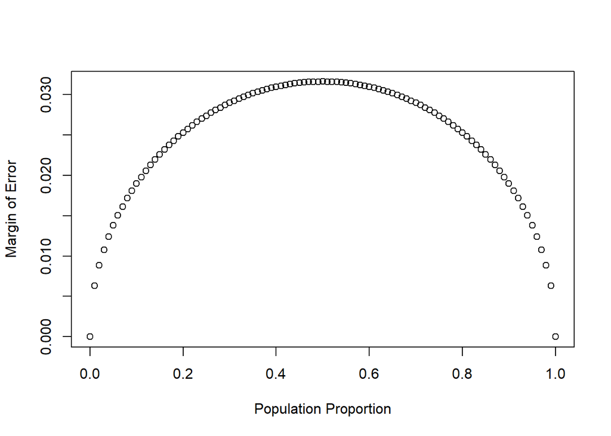

```r
n <- 1000
p <- seq(0, 1, 0.01)
me <- 2 * sqrt(p * (1 - p)/n)
plot(me ~ p, ylab = "Margin of Error", xlab = "Population Proportion")
```

## Exercise 8

Describe the relationship between p and me.

- The relationship follows a bell curve meaning you will have a lower margin of error at the very low and very high population proportions and a high magin of error the closer you sample size is to 50% of the population.

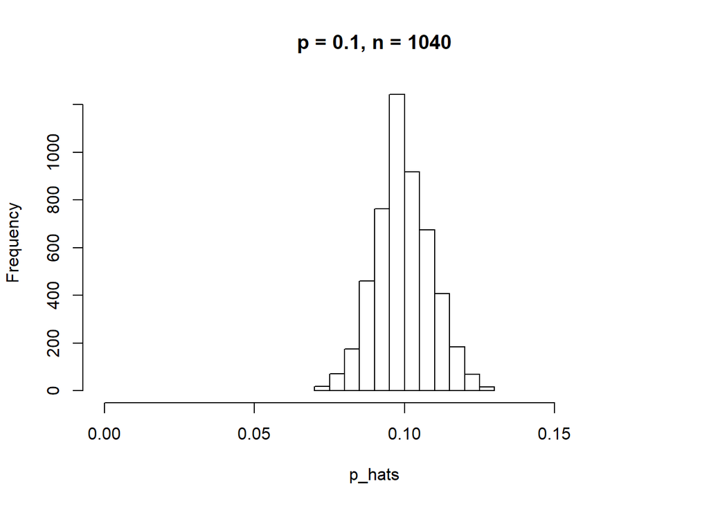

```r
p <- 0.1
n <- 1040
p_hats <- rep(0, 5000)

for(i in 1:5000){
  samp <- sample(c("atheist", "non_atheist"), n, replace = TRUE, prob = c(p, 1-p))
  p_hats[i] <- sum(samp == "atheist")/n
}

hist(p_hats, main = "p = 0.1, n = 1040", xlim = c(0, 0.18))
```

## Exercise 9

#### Describe the sampling distribution of sample proportions at n=1040 and p=0.1. Be sure to note the center, spread, and shape.

Hint: Remember that R has functions such as mean to calculate summary statistics.

```r
summary(p_hats)
```

```
##    Min. 1st Qu.  Median    Mean 3rd Qu.    Max.
## 0.07019 0.09327 0.09904 0.09969 0.10577 0.12981
```

#### The sampleing distribution is fairly normal.

## Exercise 10

#### Repeat the above simulation three more times but with modified sample sizes and proportions: for n=400 and p=0.1, n=1040 and p=0.02, and n=400 and p=0.02. Plot all four histograms together by running the par(mfrow = c(2, 2)) command before creating the histograms. You may need to expand the plot window to accommodate the larger two-by-two plot. Describe the three new sampling distributions. Based on these limited plots, how does n appear to affect the distribution of p^? How does p affect the sampling distribution?

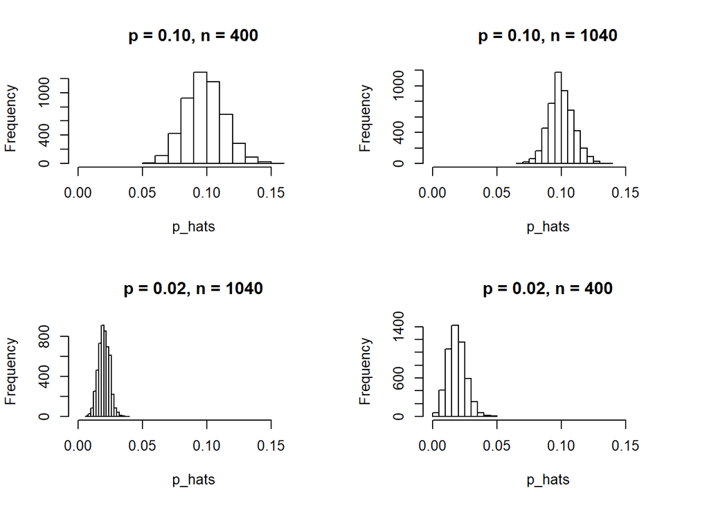

```r
p_list <- c(0.1, 0.1, 0.02, 0.02)
n_list <- c(400, 1040, 1040, 400)
par(mfrow = c(2, 2))
for(i in 1:length(p_list)){
  p_hats <- rep(0,5000)
  for(j in 1:5000){
    p <- p_list[i]
    n <- n_list[i]
    samp <- sample(c("atheist", "non_atheist"), n, replace = TRUE, prob = c(p, 1-p))
    p_hats[j] <- sum(samp == "atheist")/n
  }
  hist(p_hats, main = sprintf("p = %.2f, n = %i", p, n), xlim = c(0, 0.18))
}
```

```r
par(mfrow = c(1, 1))
```

## Exercise 11

If you refer to Table 6, you’ll find that Australia has a sample proportion of 0.1 on a sample size of 1040, and that Ecuador has a sample proportion of 0.02 on 400 subjects. Let’s suppose for this exercise that these point estimates are actually the truth. Then given the shape of their respective sampling distributions, do you think it is sensible to proceed with inference and report margin of errors, as the reports does?

```r
aus12 <- subset(atheism, nationality == "Australia" & year == "2012")
ecu12 <- subset(atheism, nationality == "Ecuador" & year == "2012")
summary(aus12)
```

```
##       nationality          response        year
##  Australia  :1039   atheist    :104   Min.   :2012
##  Afghanistan:   0   non-atheist:935   1st Qu.:2012
##  Argentina  :   0                     Median :2012
##  Armenia    :   0                     Mean   :2012
##  Austria    :   0                     3rd Qu.:2012
##  Azerbaijan :   0                     Max.   :2012
##  (Other)    :   0
```

```r
summary(ecu12)
```

```
##       nationality         response        year
##  Ecuador    :404   atheist    :  8   Min.   :2012
##  Afghanistan:  0   non-atheist:396   1st Qu.:2012
##  Argentina  :  0                     Median :2012
##  Armenia    :  0                     Mean   :2012
##  Australia  :  0                     3rd Qu.:2012
##  Austria    :  0                     Max.   :2012
##  (Other)    :  0
```

## Activity 1

Answer the following two questions using the inference function. As always, write out the hypotheses for any tests you conduct and outline the status of the conditions for inference.

- 1. Is there convincing evidence that Spain has seen a change in its atheism index between 2005 and 2012? Hint: Create a new data set for respondents from Spain. Form confidence intervals for the true proportion of athiests in both years, and determine whether they overlap.
- 2. Is there convincing evidence that the United States has seen a change in its atheism index between 2005 and 2012?

#### H0 There is no convincing evidence that Spain has seen a change in its atheism index between 2005 and 2012.

#### HA There is convincing evidence that Spain has seen a change in its atheism index between 2005 and 2012.

```r
spain05_12 <- subset(atheism, nationality == "Spain" & (year == "2012" | year == "2005"))

summary(subset(spain05_12, year == "2005"))
```

```
##       nationality          response         year
##  Spain      :1146   atheist    : 115   Min.   :2005
##  Afghanistan:   0   non-atheist:1031   1st Qu.:2005
##  Argentina  :   0                      Median :2005
##  Armenia    :   0                      Mean   :2005
##  Australia  :   0                      3rd Qu.:2005
##  Austria    :   0                      Max.   :2005
##  (Other)    :   0
```

```r
summary(subset(spain05_12, year == "2012"))
```

```
##       nationality          response         year
##  Spain      :1145   atheist    : 103   Min.   :2012
##  Afghanistan:   0   non-atheist:1042   1st Qu.:2012
##  Argentina  :   0                      Median :2012
##  Armenia    :   0                      Mean   :2012
##  Australia  :   0                      3rd Qu.:2012
##  Austria    :   0                      Max.   :2012
##  (Other)    :   0
```

```r
inference(spain05_12$response, x = spain05_12$year, est = "proportion", type = "ht", method = "theoretical",success = "atheist", alternative = "twosided", null = 0)
```

```
## Response variable: categorical, Explanatory variable: categorical
## Two categorical variables
## Difference between two proportions -- success: atheist
## Summary statistics:
##              x
## y             2005 2012  Sum
##   atheist      115  103  218
##   non-atheist 1031 1042 2073
##   Sum         1146 1145 2291
```

```
## Observed difference between proportions (2005-2012) = 0.0104
##
## H0: p_2005 - p_2012 = 0
## HA: p_2005 - p_2012 != 0
## Pooled proportion = 0.0952
## Check conditions:
##    2005 : number of expected successes = 109 ; number of expected failures = 1037
##    2012 : number of expected successes = 109 ; number of expected failures = 1036
## Standard error = 0.012
## Test statistic: Z =  0.848
## p-value =  0.3966
```

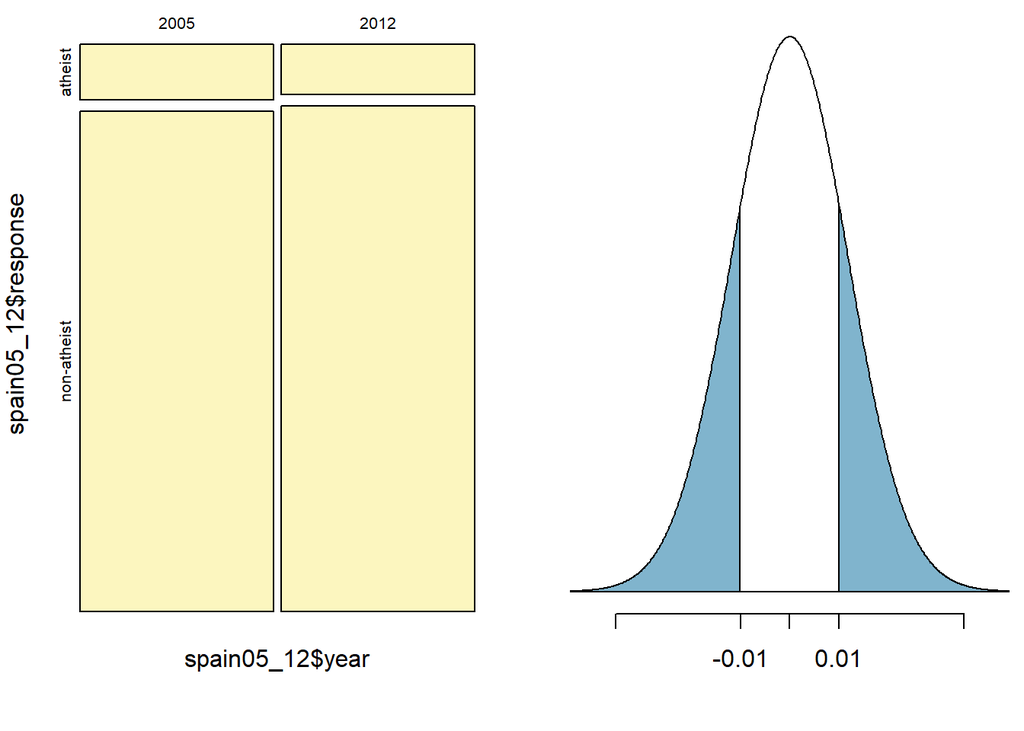

The p value is greater than 0.05, therfore we fail to reject the null hypothesis. There is not convincing evidence that Spain has seen a change in its atheism index between 2005 and 2012.

#### H0 There is no convincing evidence that the United States has seen a change in its atheism index between 2005 and 2012.

#### HA There is convincing evidence that the United States has seen a change in its atheism index between 2005 and 2012.

```r
us05_12 <- subset(atheism, nationality == "United States" & (year == "2012" | year == "2005"))

summary(subset(us05_12, year == "2005"))
```

```
##         nationality          response        year
##  United States:1002   atheist    : 10   Min.   :2005
##  Afghanistan  :   0   non-atheist:992   1st Qu.:2005
##  Argentina    :   0                     Median :2005
##  Armenia      :   0                     Mean   :2005
##  Australia    :   0                     3rd Qu.:2005
##  Austria      :   0                     Max.   :2005
##  (Other)      :   0
```

```r
summary(subset(us05_12, year == "2012"))
```

```
##         nationality          response        year
##  United States:1002   atheist    : 50   Min.   :2012
##  Afghanistan  :   0   non-atheist:952   1st Qu.:2012
##  Argentina    :   0                     Median :2012
##  Armenia      :   0                     Mean   :2012
##  Australia    :   0                     3rd Qu.:2012
##  Austria      :   0                     Max.   :2012
##  (Other)      :   0
```

```r
inference(us05_12$response, x = us05_12$year, est = "proportion", type = "ht", method = "theoretical",success = "atheist", alternative = "twosided", null = 0)
```

```
## Response variable: categorical, Explanatory variable: categorical
## Two categorical variables
## Difference between two proportions -- success: atheist
## Summary statistics:
##              x
## y             2005 2012  Sum
##   atheist       10   50   60
##   non-atheist  992  952 1944
##   Sum         1002 1002 2004
```

```
## Observed difference between proportions (2005-2012) = -0.0399
##
## H0: p_2005 - p_2012 = 0
## HA: p_2005 - p_2012 != 0
## Pooled proportion = 0.0299
## Check conditions:
##    2005 : number of expected successes = 30 ; number of expected failures = 972
##    2012 : number of expected successes = 30 ; number of expected failures = 972
## Standard error = 0.008
## Test statistic: Z =  -5.243
## p-value =  0
```

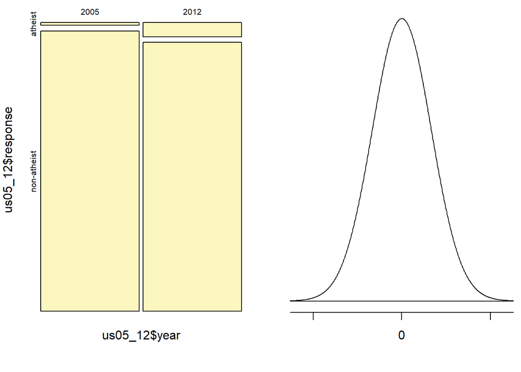

The p value is less than 0.05, therfore we reject the null hypothesis. There is convincing evidence that the United States has seen a change in its atheism index between 2005 and 2012.

## Activity 2

#### If in fact there has been no change in the atheism index in the countries listed in Table 4, in how many of those countries would you expect to detect a change (at a significance level of 0.05) simply by chance?

Hint: Look in the textbook index under Type 1 error.

At a 0.05 significance level we accept a type 1 error, rejecting the null hypothesis when it is actually true, about 5% of the time. Therefore we would execpt to detect a change in 2 countries.

```r
# Significance
act2_s <- 0.05
# Number of countries in table 4
act2_n <- 40
act2_s*act2_n
```

```
## [1] 2
```

## Activity 3

#### Suppose you’re hired by the local government to estimate the proportion of residents that attend a religious service on a weekly basis. According to the guidelines, the estimate must have a margin of error no greater than 1% with 95% confidence. You have no idea what to expect for p. How many people would you have to sample to ensure that you are within the guidelines?

Hint: Refer to your plot of the relationship between p and margin of error. Do not use the data set to answer this question.

```r
# Using p for which ME is the highest
p <- 0.5
# Z val of 0.05 significance
Z_val <- 1.96
margin_error <- 0.01
n <- Z_val^2*p*(1-p)/margin_error^2
```

We would need **9604** people.